# Which Startups are on the Rise?

Analysis of the Top 250 Startups

By Samiksha Boinpalli

# **1. Introduction:**

The reason that I chose this dataset is because of the growth in popularity and abundance of startups in recent years. I believe this trend reflects the increasing amount of competitiveness and innovation as more entrepreneurs seek to sell their products and ideas, which is truly exciting. Considering this, by analyzing this dataset, I hope to better understand and compare how industry sectors, time, and any other factors could play a role in a startup’s success.

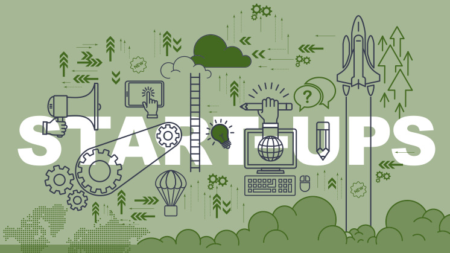

*What are startups or emerging companies and how do they work?* (2025). Iberdrola. https://www.iberdrola.com

# **2. Data Preparation:**

In order to obtain my data from the website, I had to **manually scrape** it, past it into a spreadsheet, and then download as a CSV. One challenge that I faced was that the notation valuations varied. The first steps I took to process and clean my data was taking several of the character variables that represented monetary values and **converted them to numeric values**, so that it would be easier to analyze these numbers. Then, I created **two new variables of interest**. One was the Net Money Raised, which was calculated by subtracting the money raised at publication variable from the current money raised variable. The other variable was The Valuation Growth Percentage, which was found by subtracting the valuation at publication variable from the current valuation variable, then dividing that value by the valuation at the time of publication variable, and finally multiplying that value by a 100. One **challenge** faced was that the data often had inconsistent notations. For instance, numbers in the millions were denoted as both “M” and “millions”. In addition, there was also values such as “B”, “NA”, “Unknown”, and more. To handle these inconsistencies, I used conditional or statement for different representations of millions, if statements to differentiate between millions and billions, and assigned NA to any values that were not numeric. In general, for any **NA and unknown values**, I converted them all to NA, so that they wouldn’t disrupt any calculations with numeric values. Lastly, there was a total of **250 observations, representing 250 different startups**; 50 from each year from 2020-2024.

# **3. Variable Descriptions:**

**Information about the Variables Used for Analysis.**

| Variable Name | Type | Description |
| --- | --- | --- |
| name.of.company | Categorical | The name of the startup. |
| year.included | Categorical | The year that the startup was included on this list. |
| sector | Categorical | The industry sector that the startup belongs to. |
| revenue.at.time.of.publication | Numeric | The total revenue of the startup at time of publication |
| net.money.raised | Numeric | The total net change in the money raised by the startup from publication time to current time. |
| valuation_growth_percentage | Numeric | The percentage growth in the startup from the publication time to current time. |

# **4. Univariate Analyses:**

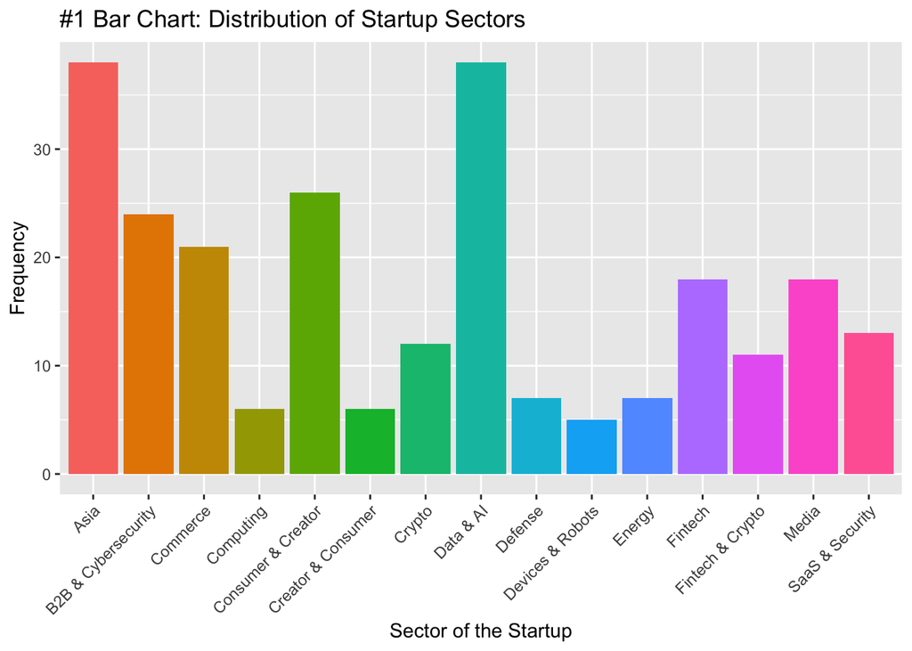

As evident, the distribution of startup sectors varies greatly, with Data & AI and Asia dominating the startup market with both sectors having counts of 38 startups in the top 250 startups. On the other hand, Devices & Robots is the least common sector in the Top 50 Startups with a minimum count of only 5 startups.

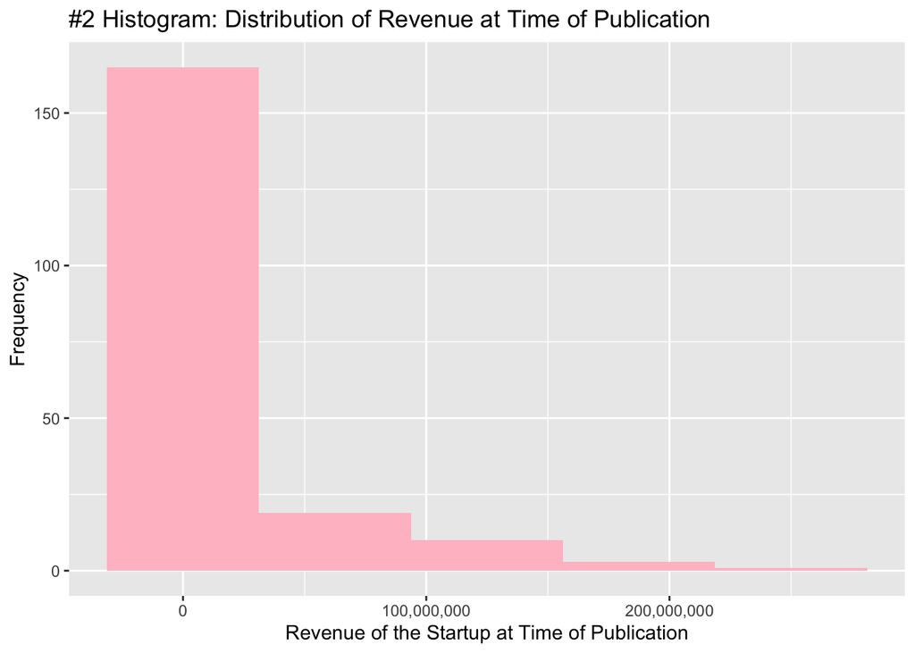

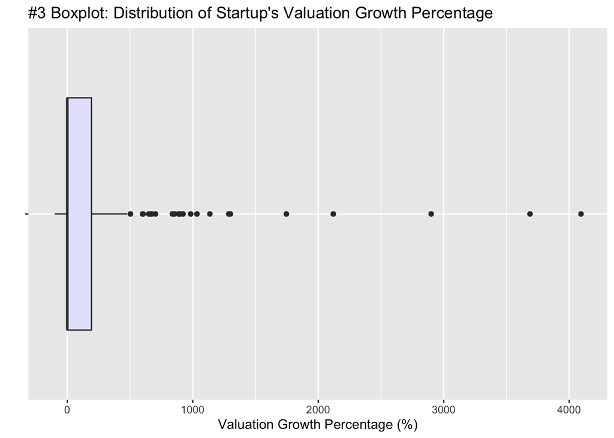

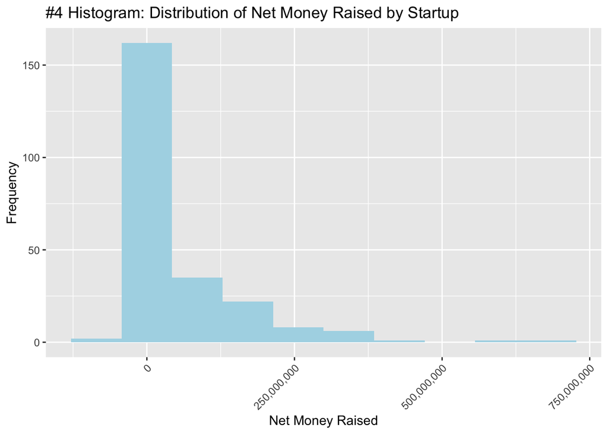

This histogram displays a right-skewed distribution, of Net Money Raised by startups with a media net money raised of 0.3 million. The greatest amount of net money raised was 679 while the lowest was -90.76 million. As we see the median to be closer to the minimum net money raised, it can be concluded that while most companies experience modest growth in funding, only a few experience huge increases in funding.